# Hayman Fire Recovery

Assignment by Matthew Ross, completed by Marian Hsieh

02/03/2022

```r
library(tidyverse)
library(tidyr)
library(ggthemes)
library(lubridate)

# Now that we have learned how to munge (manipulate) data
# and plot it, we will work on using these skills in new ways

knitr::opts_knit$set(root.dir='..')
```

```r
####-----Reading in Data and Stacking it ----- ####
#Reading in files
files <- list.files('data',full.names=T)

#Read in individual data files
ndmi <- read_csv(files[1]) %>%
  rename(burned=2,unburned=3) %>%
  mutate(data='ndmi')

ndsi <- read_csv(files[2]) %>%
  rename(burned=2,unburned=3) %>%
  mutate(data='ndsi')

ndvi <- read_csv(files[3])%>%
  rename(burned=2,unburned=3) %>%
  mutate(data='ndvi')

#Stack as a tidy dataset
full_long <- rbind(ndvi,ndmi,ndsi) %>%
  gather(key='site',value='value',-DateTime,-data) %>%
  filter(!is.na(value))
```

## Question 1

What is the correlation between NDVI and NDMI? - here I want you to convert the full_long dataset in to a wide dataset using the function “spread” and then make a plot that shows the correlation as a function of if the site was burned or not (x axis should be ndmi) You should exclude winter months and focus on summer months

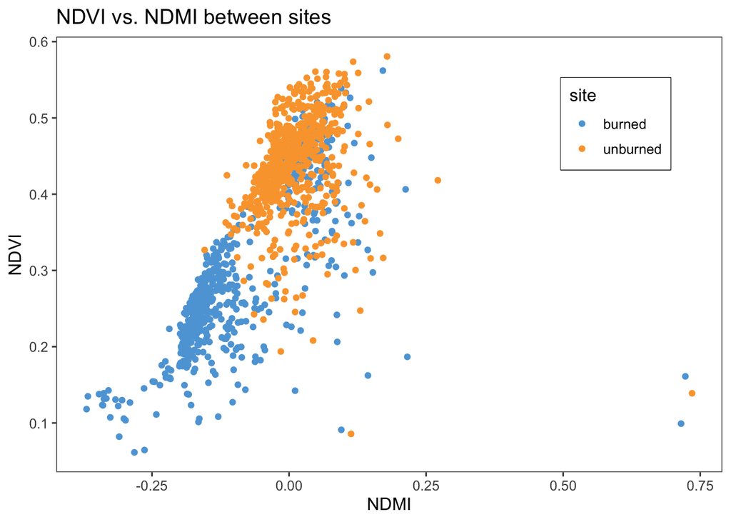

```r
#Code adapted from "assignment_1" script and re-written in modern tidyverse syntax (Bonus #1)
#Convert from long to wide & filter for summer months only
full_wide <- full_long %>%
  filter(month(DateTime) %in% c(6,7,8,9)) %>%
  pivot_wider(names_from=data,values_from=value)

#Plot NDVI vs. NDMI (by burned/unburned)
ggplot(full_wide,aes(x=ndmi,y=ndvi,color=site)) +
  geom_point() +
  theme_few() +
  scale_color_few() +
  theme(legend.position=c(0.84,0.8),
        legend.box.background=element_rect(fill="grey")) +
  ggtitle("NDVI vs. NDMI between sites") + xlab("NDMI") + ylab("NDVI")
```

```r
#Summary stats for NDVI vs. NDMI
summary.lm(lm(ndvi~ndmi,data=full_wide))
```

[output not shown]

Answer: There is a significantly positive correlation between NDVI and NDMI.

## Question 2

2. What is the correlation between average NDSI (normalized snow index) for January-April and average NDVI for June-August? In other words, does the previous year’s snow cover influence vegetation growth for the following summer?

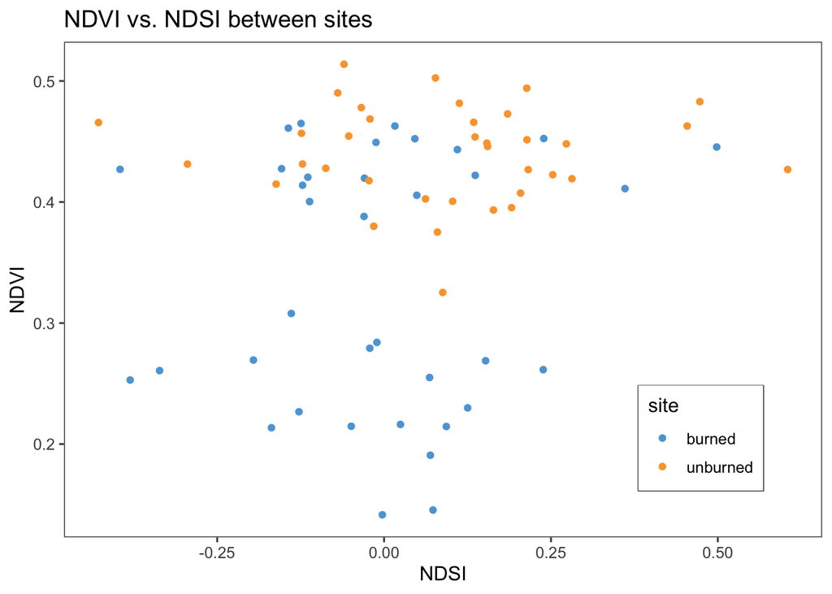

```r
#Filter & average NDSI from Jan-April
ndsi_months <- full_long %>%
  filter(data=="ndsi",month(DateTime) %in% c(1,2,3,4)) %>%
  group_by(year(DateTime),site) %>%
  summarize(mean=mean(value),data="ndsi")

#Filter & average NDVI from June-Aug
ndvi_months <- full_long %>%
  filter(data=="ndvi",month(DateTime) %in% c(6,7,8)) %>%
  group_by(year(DateTime),site) %>%
  summarize(mean=mean(value),data="ndvi")

#Stack datasets
months_avg <- rbind(ndsi_months,ndvi_months) %>%
  pivot_wider(names_from=data,values_from=mean)

#Plot NDVI vs. NDSI (by burned/unburned)
ggplot(months_avg,aes(x=ndsi,y=ndvi,color=site)) +
  geom_point() +
  theme_few() +
  scale_color_few() +
  theme(legend.position=c(0.84,0.2),
        legend.box.background=element_rect(fill="grey")) +
  ggtitle("NDVI vs. NDSI between sites") + xlab("NDSI") + ylab("NDVI")
```

```r
#Summary stats for NDVI vs. NDSI
summary.lm(lm(ndvi~ndsi,data=months_avg))
```

[output not shown]

Answer: There is no significant correlation between winter/spring NDSI and summer NDVI.

## Question 3

How is the snow effect from question 2 different between pre- and post-burn and burned and unburned?

```r
#Summary stats for NDSI/NDVI between burned/unburned sites
summary.lm(lm(ndvi~ndsi,data=subset(months_avg,site=="burned")))
summary.lm(lm(ndvi~ndsi,data=subset(months_avg,site=="unburned")))
```

[output not shown]

Answer: There is no significant effect of winter/spring NDSI on summer NDVI between burned and unburned sites.

## Question 4

What month is the greenest month on average?

```r
#Group NDVI by month
ndvi_year <- full_long %>%
  filter(data=="ndvi") %>%
  group_by(month(DateTime)) %>%
  summarize(mean=mean(value),data="ndvi")

#Determine which month has highest NDVI mean
which.max(ndvi_year$mean)
```

[output not shown]

Answer: The greenest month is August.

## Question 5

What month is the snowiest on average?

```r
#Group NDSI by month
ndsi_year <- full_long %>%
  filter(data=="ndsi") %>%
  group_by(month(DateTime)) %>%
  summarize(mean=mean(value),data="ndsi")

#Determine which month has highest NDSI mean
which.max(ndsi_year$mean)
```

[output not shown]

Answer: The snowiest month is January.

## Bonus Question: Redo all problems with `spread` and `gather` using modern tidyverse syntax.

Changed within chunks above.